# Unit 2 Project

Leila Haidar

2026-02-04

## **Lecture 6**

install.packages(“tidyverse”) install.packages(“palmerpenguins”)

```r
library("tidyverse")
library("palmerpenguins")
penguins <- penguins %>%
  drop_na(flipper_length_mm, body_mass_g, bill_length_mm, bill_depth_mm, sex)
```

### **Q1**

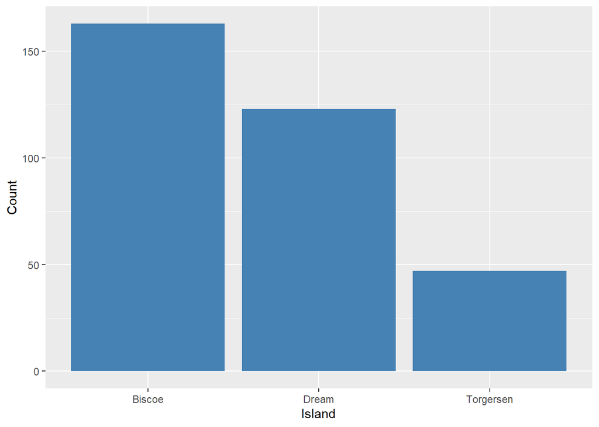

```r
ggplot(penguins, aes(x = island)) +
  geom_bar(fill = "steelblue") +
  labs(x = "Island", y = "Count")
```

Biscoe has the most penguins

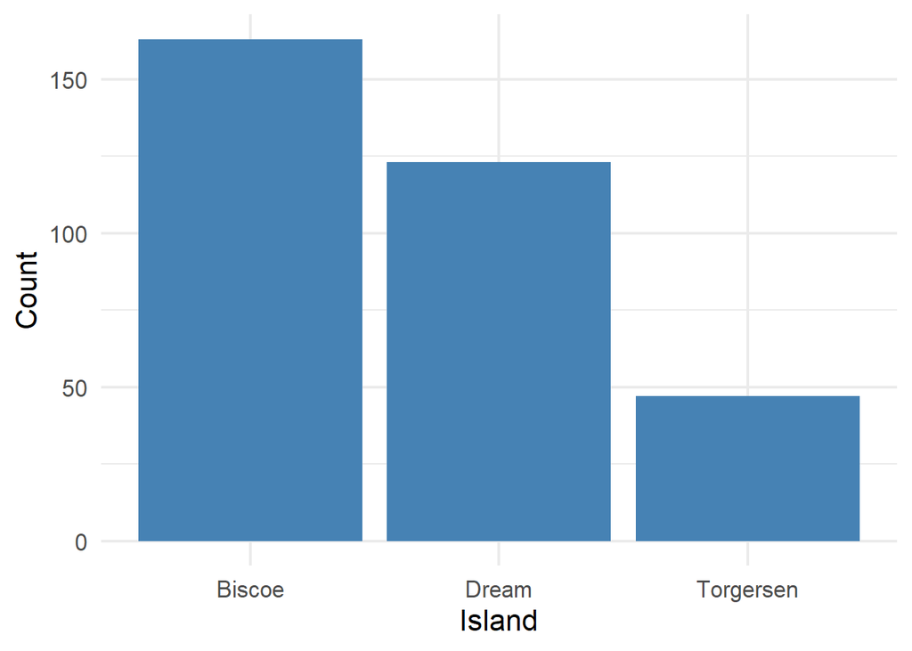

```r
ggplot(penguins, aes(x = island)) +
  geom_bar(fill = "steelblue") +
  labs(x = "Island", y = "Count") +
  theme_minimal(base_size = 16)
```

Adding theme_minimal() makes the graph look cleaner/more visually sound.

### **Q2**

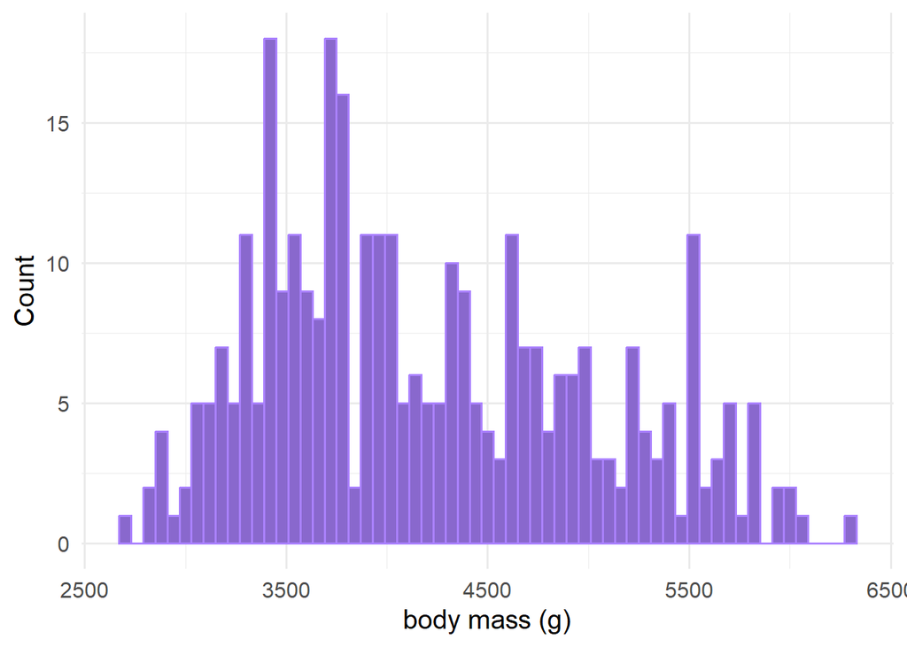

```r
ggplot(penguins, aes(x = body_mass_g)) +
  geom_histogram(binwidth = 60,
                 fill = "mediumpurple3",
                 color = "mediumpurple1") +
  labs(x = "body mass (g)",
       y = "Count") +
  theme_minimal(base_size = 15)
```

The general shape of the distribution is normal with a right skew. Changing bin number changes the range of the x-axis, or body mass.

### **Q3**

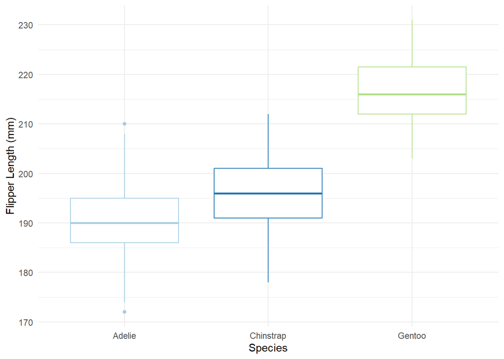

```r
ggplot(penguins,
       aes(x = species,
           y = flipper_length_mm,
           color = species)) +
  geom_boxplot() +
  labs(x = "Species", y="Flipper Length (mm)")+
  theme_minimal()+
  scale_color_brewer(palette = "Paired")+
  theme(legend.position = "none")
```

Gentoo have longest flippers (~216 mm average)

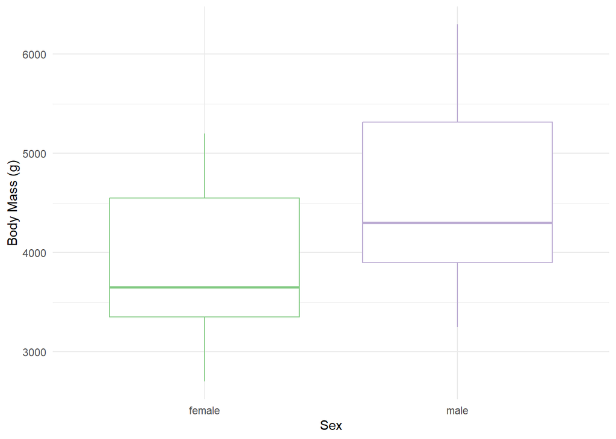

```r
ggplot(penguins,
       aes(x = sex,
           y = body_mass_g,
           color = sex)) +
  geom_boxplot() +
  labs(x = "Sex", y="Body Mass (g)")+
  theme_minimal()+
  scale_color_brewer(palette = "Accent")+
  theme(legend.position = "none")
```

Males have on average a higher body mass.

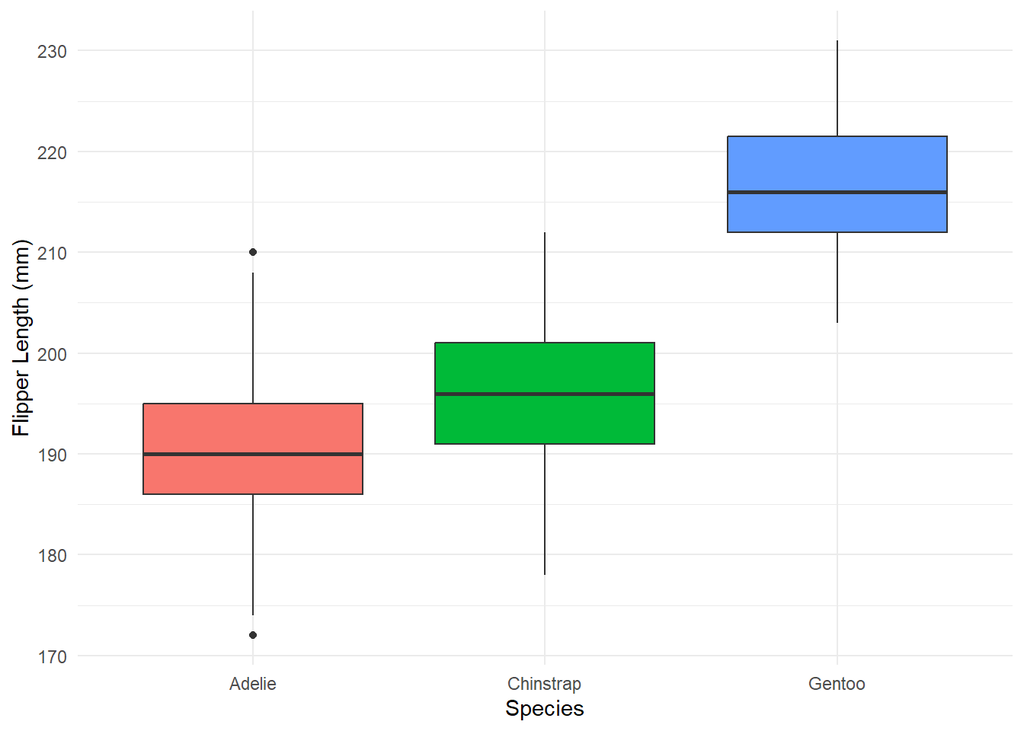

```r
ggplot(penguins,
       aes(x = species,
           y = flipper_length_mm,
           fill = species)) +
  geom_boxplot() +
  labs(x = "Species", y="Flipper Length (mm)")+
  theme_minimal()+
  theme(legend.position = "none")
```

### **Q4**

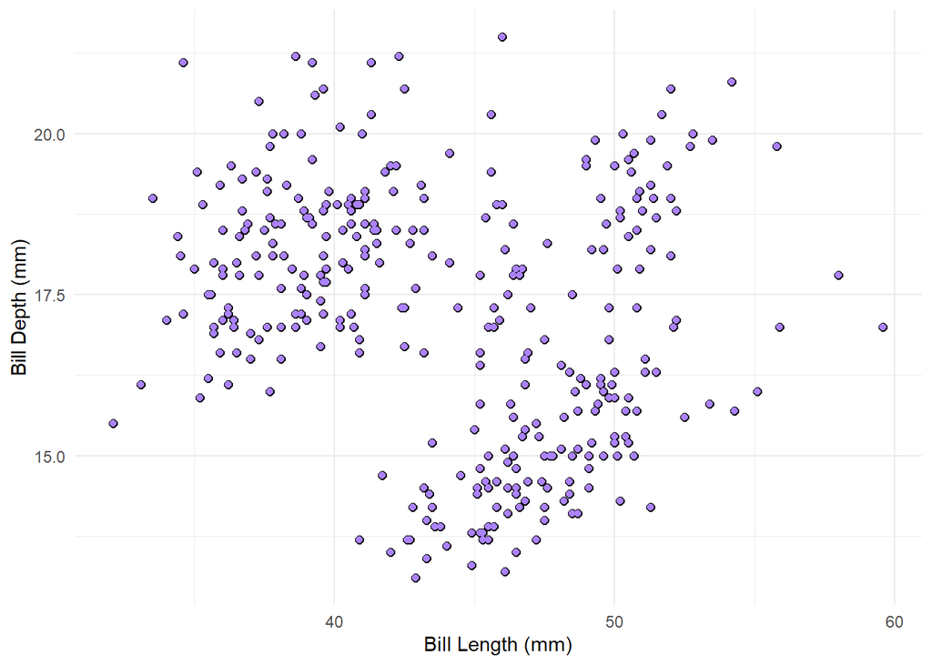

```r
ggplot(penguins,
       aes(x = bill_length_mm,
           y = bill_depth_mm)) +
  geom_point(size = 2)+
  geom_point(color = "mediumpurple1")+
  labs(x = "Bill Length (mm)",
       y = "Bill Depth (mm)")+
    theme_minimal()
```

The relationship of the scatterplot is unclear. Adding a color makes the scatterplot slightly more readable, however overall still unclear.

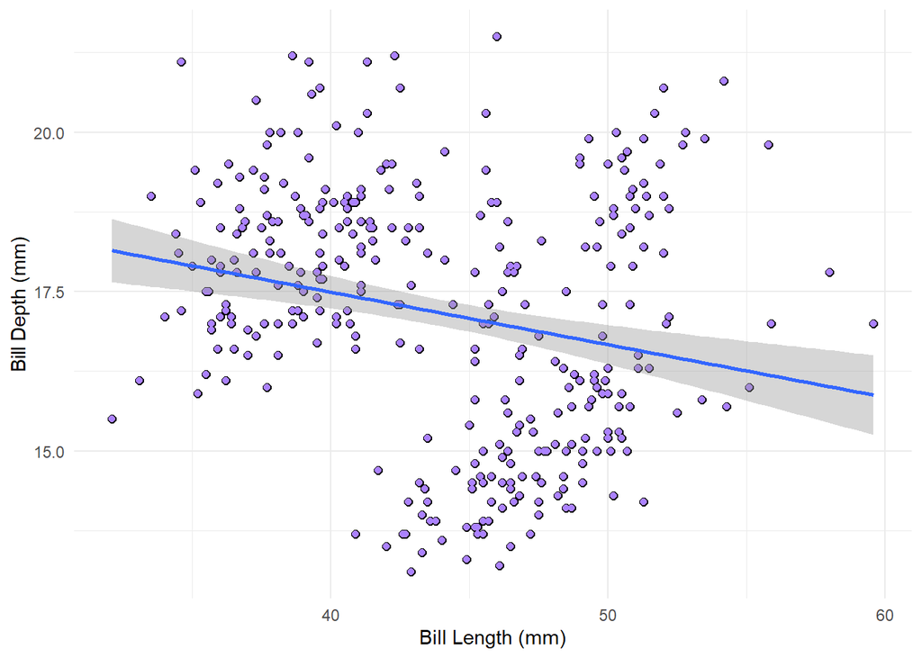

```r
ggplot(penguins,
       aes(x = bill_length_mm,
           y = bill_depth_mm)) +
  geom_point(size = 2)+
  geom_point(color = "mediumpurple1")+
  labs(x = "Bill Length (mm)",
       y = "Bill Depth (mm)")+
  theme_minimal()+
  geom_smooth(method="lm", na.rm=TRUE)
```

Adding the line of best fit shows a slight negative relationship between Bill Length and Depth. Overall, however, the line does not fit the data well.

### **Q5**

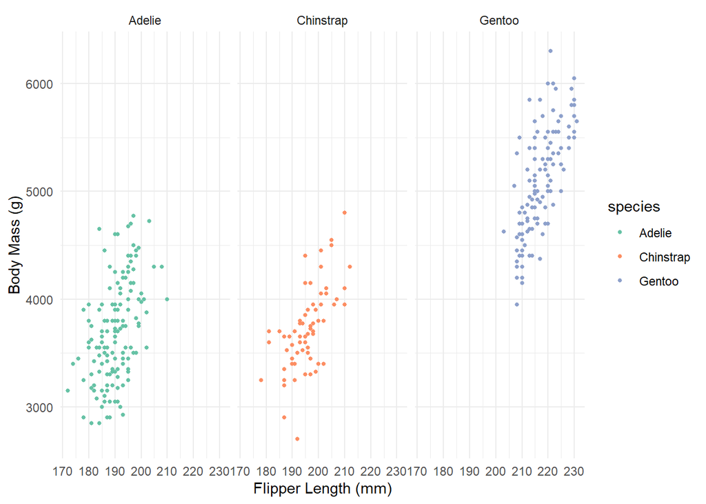

```r
ggplot(penguins,
       aes(x = flipper_length_mm,
           y = body_mass_g,
           color = species)) +
  geom_point(size = 1)+
  facet_wrap(~species)+
  labs(x = "Flipper Length (mm)",
       y = "Body Mass (g)")+
  theme_minimal()+
  scale_color_brewer(palette="Set2")
```

The Gentoo species shows the strongest relationship with Body mass and Flipper length.

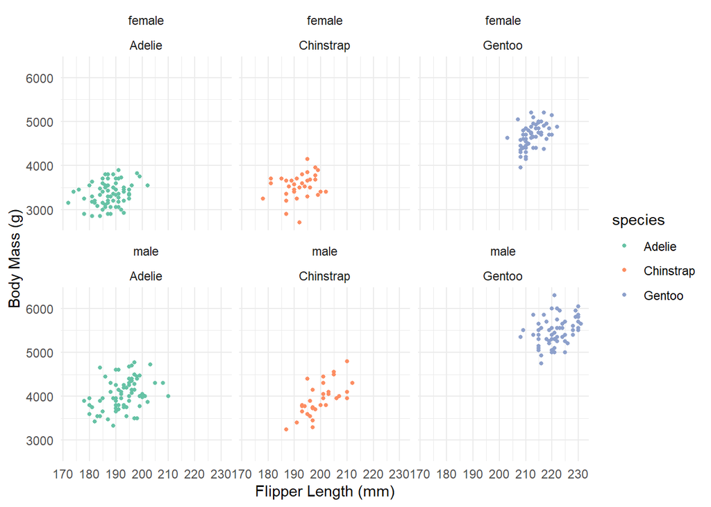

```r
ggplot(penguins,
       aes(x = flipper_length_mm,
           y = body_mass_g,
           color = species)) +
  geom_point(size = 1)+
  facet_wrap(sex~species)+
  labs(x = "Flipper Length (mm)",
       y = "Body Mass (g)")+
  theme_minimal()+
  scale_color_brewer(palette="Set2")
```

The pattern indicates that male Gentoo penguins have the highest body mass. Additionally, body mass is generally higher among males, and Gentoo penguins are larger for both sexes.

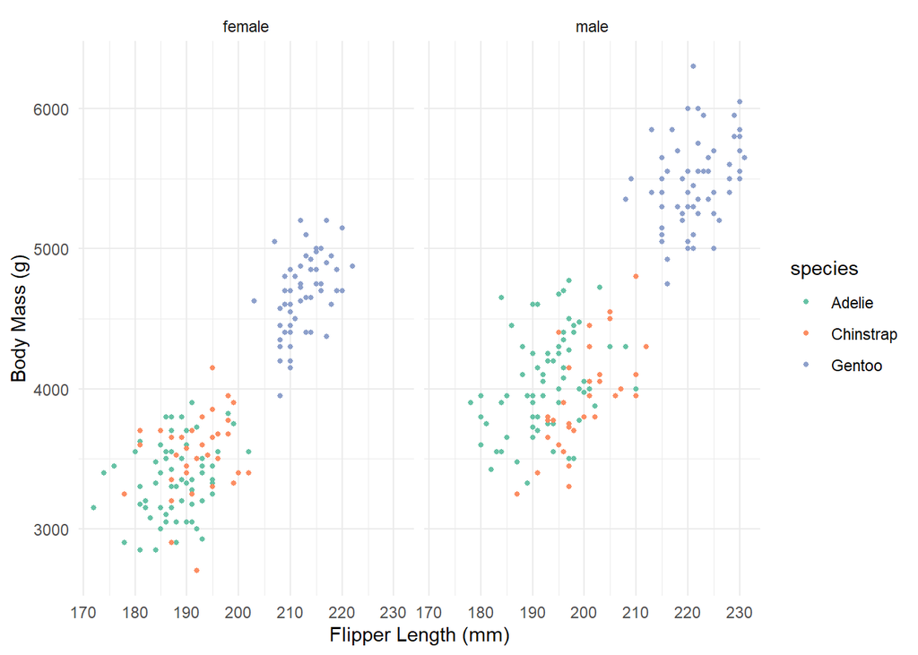

```r
ggplot(penguins,
       aes(x = flipper_length_mm,
           y = body_mass_g,
           color = species)) +
  geom_point(size = 1)+
  facet_wrap(~species)+
  facet_wrap(~sex)+
  labs(x = "Flipper Length (mm)",
       y = "Body Mass (g)")+
  theme_minimal()+
  scale_color_brewer(palette="Set2")
```

### **Q6**

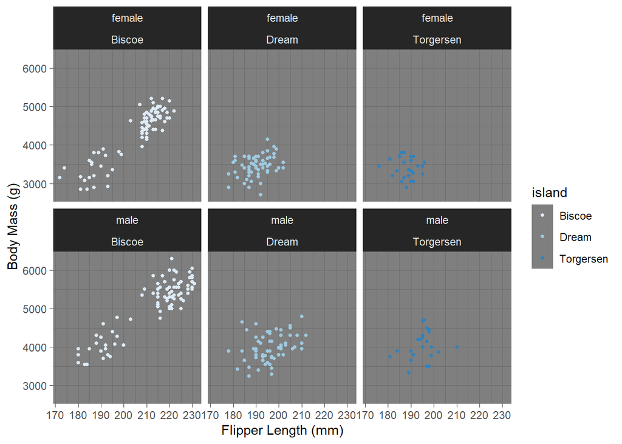

```r
files<-ggplot(penguins,
       aes(x = flipper_length_mm,
           y = body_mass_g,
           color = island)) +
  geom_point(size = 1)+
  facet_wrap(sex~island)+
  labs(x = "Flipper Length (mm)",
       y = "Body Mass (g)")+
  theme_dark()+
  scale_color_brewer(palette="Blues")
files
```

### **Q7**

- The most fun part of the exercise was being able to customize the colors of different graphs, and create my own graph.
- The most confusing part of the exercise was determining the parameters format for each type of graph.

## **Lecture 7**

```r
library("palmerpenguins")
library("dplyr")
library("tidyverse")
library(readr)
penguins_messy <- read_csv("penguins_messy.csv")
view(penguins_messy)
```

### **Q1**

```r
str_detect(penguins_messy$species_messy, "adelie")
```

```
##   [1]  TRUE  TRUE  TRUE  TRUE  TRUE  TRUE  TRUE  TRUE  TRUE  TRUE  TRUE  TRUE
##  [13]  TRUE  TRUE  TRUE  TRUE  TRUE  TRUE  TRUE  TRUE  TRUE  TRUE  TRUE  TRUE
##  [25]  TRUE  TRUE  TRUE  TRUE  TRUE  TRUE  TRUE  TRUE  TRUE  TRUE  TRUE  TRUE
##  [37]  TRUE  TRUE  TRUE  TRUE  TRUE  TRUE  TRUE  TRUE  TRUE  TRUE  TRUE  TRUE
##  [49]  TRUE  TRUE  TRUE  TRUE  TRUE  TRUE  TRUE  TRUE  TRUE  TRUE  TRUE  TRUE
##  [61]  TRUE  TRUE  TRUE  TRUE  TRUE  TRUE  TRUE  TRUE  TRUE  TRUE  TRUE  TRUE
##  [73]  TRUE  TRUE  TRUE  TRUE  TRUE  TRUE  TRUE  TRUE  TRUE  TRUE  TRUE  TRUE
##  [85]  TRUE  TRUE  TRUE  TRUE  TRUE  TRUE  TRUE  TRUE  TRUE  TRUE  TRUE  TRUE
##  [97]  TRUE  TRUE  TRUE  TRUE  TRUE  TRUE  TRUE  TRUE  TRUE  TRUE  TRUE  TRUE
## [109]  TRUE  TRUE  TRUE  TRUE  TRUE  TRUE  TRUE  TRUE  TRUE  TRUE  TRUE  TRUE
## [121]  TRUE  TRUE  TRUE  TRUE  TRUE  TRUE  TRUE  TRUE  TRUE  TRUE  TRUE  TRUE
## [133]  TRUE  TRUE  TRUE  TRUE  TRUE  TRUE  TRUE  TRUE  TRUE  TRUE  TRUE  TRUE
## [145]  TRUE  TRUE  TRUE  TRUE  TRUE  TRUE  TRUE  TRUE FALSE FALSE FALSE FALSE
## [157] FALSE FALSE FALSE FALSE FALSE FALSE FALSE FALSE FALSE FALSE FALSE FALSE
## [169] FALSE FALSE FALSE FALSE FALSE FALSE FALSE FALSE FALSE FALSE FALSE FALSE
## [181] FALSE FALSE FALSE FALSE FALSE FALSE FALSE FALSE FALSE FALSE FALSE FALSE
## [193] FALSE FALSE FALSE FALSE FALSE FALSE FALSE FALSE FALSE FALSE FALSE FALSE
## [205] FALSE FALSE FALSE FALSE FALSE FALSE FALSE FALSE FALSE FALSE FALSE FALSE
## [217] FALSE FALSE FALSE FALSE FALSE FALSE FALSE FALSE FALSE FALSE FALSE FALSE
## [229] FALSE FALSE FALSE FALSE FALSE FALSE FALSE FALSE FALSE FALSE FALSE FALSE
## [241] FALSE FALSE FALSE FALSE FALSE FALSE FALSE FALSE FALSE FALSE FALSE FALSE
## [253] FALSE FALSE FALSE FALSE FALSE FALSE FALSE FALSE FALSE FALSE FALSE FALSE
## [265] FALSE FALSE FALSE FALSE FALSE FALSE FALSE FALSE FALSE FALSE FALSE FALSE
## [277] FALSE FALSE FALSE FALSE FALSE FALSE FALSE FALSE FALSE FALSE FALSE FALSE
## [289] FALSE FALSE FALSE FALSE FALSE FALSE FALSE FALSE FALSE FALSE FALSE FALSE
## [301] FALSE FALSE FALSE FALSE FALSE FALSE FALSE FALSE FALSE FALSE FALSE FALSE
## [313] FALSE FALSE FALSE FALSE FALSE FALSE FALSE FALSE FALSE FALSE FALSE FALSE
## [325] FALSE FALSE FALSE FALSE FALSE FALSE FALSE FALSE FALSE FALSE FALSE FALSE
## [337] FALSE FALSE FALSE FALSE FALSE FALSE FALSE FALSE
```

```r
?str_detect
```

```
## starting httpd help server ... done
```

Detects matching values, or if any values contain “adelie”

```r
str_replace_all(penguins_messy$sex_messy, "\\?", "")
```

```
##   [1] "M" "f" "f" NA  "f" "M" "f" "M" NA  NA  NA  NA  "f" "M" "M" "f" "f" "M"
##  [19] "f" "M" "f" "M" "f" "M" "M" "f" "M" "f" "f" "M" "f" "M" "f" "M" "f" "M"
##  [37] "M" "f" "f" "M" "f" "M" "f" "M" "f" "M" "M" NA  "f" "M" "f" "M" "f" "M"
##  [55] "f" "M" "f" "M" "f" "M" "f" "M" "f" "M" "f" "M" "f" "M" "f" "M" "f" "M"
##  [73] "f" "M" "f" "M" "f" "M" "f" "M" "f" "M" "f" "M" "f" "M" "M" "f" "M" "f"
##  [91] "f" "M" "f" "M" "f" "M" "f" "M" "f" "M" "f" "M" "f" "M" "f" "M" "f" "M"
## [109] "f" "M" "f" "M" "f" "M" "f" "M" "f" "M" "f" "M" "f" "M" "f" "M" "f" "M"
## [127] "f" "M" "f" "M" "f" "M" "f" "M" "f" "M" "f" "M" "f" "M" "f" "M" "f" "M"
## [145] "f" "M" "M" "f" "f" "M" "f" "M" "f" "M" "f" "M" "M" "f" "f" "M" "f" "M"
## [163] "f" "M" "f" "M" "f" "M" "f" "M" "f" "M" "M" "f" "f" "M" "f" "M" NA  "M"
## [181] "f" "M" "M" "f" "f" "M" "f" "M" "f" "M" "f" "M" "f" "M" "f" "M" "M" "f"
## [199] "f" "M" "f" "M" "f" "M" "f" "M" "f" "M" "f" "M" "f" "M" "f" "M" "f" "M"
## [217] "f" "M" NA  "M" "f" "M" "f" "M" "M" "f" "f" "M" "f" "M" "f" "M" "f" "M"
## [235] "f" "M" "f" "M" "f" "M" "f" "M" "f" "M" "f" "M" "f" "M" "M" "f" "f" "M"
## [253] "f" "M" "f" "M" NA  "M" "f" "M" "f" "M" "f" "M" "f" "M" "f" "M" NA  "M"
## [271] "f" NA  "f" "M" "f" "M" "f" "M" "M" "f" "M" "f" "f" "M" "f" "M" "f" "M"
## [289] "f" "M" "f" "M" "M" "f" "f" "M" "f" "M" "f" "M" "f" "M" "f" "M" "f" "M"
## [307] "f" "M" "f" "M" "M" "f" "f" "M" "f" "M" "M" "f" "M" "f" "f" "M" "f" "M"
## [325] "M" "f" "f" "M" "f" "M" "f" "M" "f" "M" "M" "f" "M" "f" "f" "M" "f" "M"
## [343] "M" "f"
```

```r
?str_replace_all
```

Replaces matching penguin sex values with a new text

```r
str_squish(penguins_messy$island_messy)
```

```
##   [1] "Torgersen" "Torgersen" "Torgersen" "Torgersen" "Torgersen" "Torgersen"
##   [7] "Torgersen" "Torgersen" "Torgersen" "Torgersen" "Torgersen" "Torgersen"
##  [13] "Torgersen" "Torgersen" "Torgersen" "Torgersen" "Torgersen" "Torgersen"
##  [19] "Torgersen" "Torgersen" "BIS-COE"   "BIS-COE"   "BIS-COE"   "BIS-COE"
##  [25] "BIS-COE"   "BIS-COE"   "BIS-COE"   "BIS-COE"   "BIS-COE"   "BIS-COE"
##  [31] "Dream"     "Dream"     "Dream"     "Dream"     "Dream"     "Dream"
##  [37] "Dream"     "Dream"     "Dream"     "Dream"     "Dream"     "Dream"
##  [43] "Dream"     "Dream"     "Dream"     "Dream"     "Dream"     "Dream"
##  [49] "Dream"     "Dream"     "BIS-COE"   "BIS-COE"   "BIS-COE"   "BIS-COE"
##  [55] "BIS-COE"   "BIS-COE"   "BIS-COE"   "BIS-COE"   "BIS-COE"   "BIS-COE"
##  [61] "BIS-COE"   "BIS-COE"   "BIS-COE"   "BIS-COE"   "BIS-COE"   "BIS-COE"
##  [67] "BIS-COE"   "BIS-COE"   "Torgersen" "Torgersen" "Torgersen" "Torgersen"
##  [73] "Torgersen" "Torgersen" "Torgersen" "Torgersen" "Torgersen" "Torgersen"
##  [79] "Torgersen" "Torgersen" "Torgersen" "Torgersen" "Torgersen" "Torgersen"
##  [85] "Dream"     "Dream"     "Dream"     "Dream"     "Dream"     "Dream"
```

[output cut: 43 more lines]

```r
?str_squish
```

Removes whitespace, or spaces/line breaks, in the island category.

### **Q2**

```r
penguins_messy<-penguins_messy %>%
  mutate(valid_id = str_detect(sample_id, "PAL-[0-9]{3}"))

penguins_messy %>%
  pull(valid_id) %>%
  sum
```

```
## [1] 316
```

### **Q3**

```r
penguins_messy<- penguins_messy %>%
  filter(valid_id)
penguins_messy
```

```
## # A tibble: 316 × 7
##    species_messy island_messy sex_messy sample_id file_name       notes valid_id
##    <chr>         <chr>        <chr>     <chr>     <chr>           <chr> <lgl>
##  1 adelie        Torgersen    M         PAL-535   "2024-01-14_To… "id=… TRUE
##  2 adelie        Torgersen    f?        PAL-442   "2024-01-17_To… "id=… TRUE
##  3 adelie        Torgersen    f?        PAL-668   "2024-01-08_To… "id=… TRUE
##  4 adelie        Torgersen    <NA>      PAL-920   "2024-01-26_To… "id=… TRUE
##  5 adelie        Torgersen    f?        PAL-223   "2024-01-06_To… "id=… TRUE
##  6 adelie        Torgersen    M         PAL-899   "2024-01-08_To… "id=… TRUE
##  7 adelie        Torgersen    f?        PAL-268   "2024-01-08_To… "id=… TRUE
##  8 adelie        Torgersen    M         PAL-139   "2024-01-19_To… "id=… TRUE
##  9 adelie        Torgersen    <NA>      PAL-847   "2024-01-14_To… "id=… TRUE
## 10 adelie        Torgersen    <NA>      PAL-238   "2024-01-24_To… "id=… TRUE
## # ℹ 306 more rows
```

### **Q4**

```r
penguins_messy<-penguins_messy %>%
  mutate(
    file_date = str_extract(file_name, "^[0-9]{4}-[0-9]{2}-[0-9]{2}"),
    file_id = str_extract(sample_id, "PAL-[0-9]{3}"))

penguins_messy %>%
  filter(row_number() <= 10) %>%
  pull(file_date)
```

```
##  [1] "2024-01-14" "2024-01-17" "2024-01-08" "2024-01-26" "2024-01-06"
##  [6] "2024-01-08" "2024-01-08" "2024-01-19" "2024-01-14" "2024-01-24"
```

```r
penguins_messy %>%
  filter(row_number() <= 10) %>%
  pull(file_id)
```

```
##  [1] "PAL-535" "PAL-442" "PAL-668" "PAL-920" "PAL-223" "PAL-899" "PAL-268"
##  [8] "PAL-139" "PAL-847" "PAL-238"
```

### **Q5**

```r
penguins_messy<-penguins_messy %>%
  mutate(island=
  str_squish(island_messy))

unique(penguins_messy$island)
```

```
## [1] "Torgersen" "BIS-COE"   "Dream"
```

### **Q6**

```r
penguins_messy<-penguins_messy %>%
  mutate(sex=
  str_replace_all(sex_messy,"\\?","") %>% str_to_upper)
```

*OR*

```r
penguins_messy<-penguins_messy %>%
  mutate(sex=
  str_replace_all(sex_messy,"\\?",""))%>%
  mutate(sex=
  str_to_upper(sex))

unique(penguins_messy$sex)
```

```
## [1] "M" "F" NA
```

### **Q7**

```r
penguins_messy<-penguins_messy %>%
  mutate(bill_mm=
  str_replace_all(notes,"\\.*bill=|mm",""))

unique(penguins_messy$bill_mm)
```

```
##   [1] "id=PAL-535; island=Torgersen\t; sp=adelie; 39.1"
##   [2] "id=PAL-442; island=Torgersen\t; sp=adelie; 39.5"
##   [3] "id=PAL-668; island=Torgersen\t; sp=adelie; 40.3"
##   [4] "id=PAL-920; island=Torgersen\t; sp=adelie; NA"
##   [5] "id=PAL-223; island=Torgersen\t; sp=adelie; 36.7"
##   [6] "id=PAL-899; island=Torgersen\t; sp=adelie; 39.3"
##   [7] "id=PAL-268; island=Torgersen\t; sp=adelie; 38.9"
##   [8] "id=PAL-139; island=Torgersen\t; sp=adelie; 39.2"
##   [9] "id=PAL-847; island=Torgersen\t; sp=adelie; 34.1"
##  [10] "id=PAL-238; island=Torgersen\t; sp=adelie; 42"
##  [11] "id=PAL-528; island=Torgersen\t; sp=adelie; 37.8"
##  [12] "id=PAL-365; island=Torgersen\t; sp=adelie; 37.8"
##  [13] "id=PAL-662; island=Torgersen\t; sp=adelie; 41.1"
##  [14] "id=PAL-890; island=Torgersen\t; sp=adelie; 38.6"
##  [15] "id=PAL-907; island=Torgersen\t; sp=adelie; 34.6"
```

[output cut: 301 more lines]

### **Q8**

*Most fun/interesting part of exercise? Most confusing or difficult?*

- The most interesting part was finally figuring out how to use the different str functions in the mutate function.
- The most confusing/difficult part was also figuring out how to use the different str functions in the mutate function.

*Do you feel you have a general idea of how regular expressions are used?*

- Yes, though I will likely practice more because I only started to understand it towards the last question.

## **Lecture 8**

```r
penguins <- palmerpenguins::penguins
library("tidyverse")
library("palmerpenguins")
```

### **Q1**

```r
penguins_clean <- penguins %>%
  drop_na(bill_length_mm,sex)

nrow(penguins_clean)
```

```
## [1] 333
```

```r
nrow(penguins)
```

```
## [1] 344
```

333 rows (oenguins clean) vs 344 (penguins)

### **Q2**

```r
penguins_dup <- penguins_clean %>%
  bind_rows(slice_sample(penguins_clean, n = 30, replace = TRUE))
nrow(penguins_dup)
```

```
## [1] 363
```

```r
penguins_dup %>% distinct %>% nrow
```

```
## [1] 333
```

### **Q3**

```r
penguins_new <- penguins_clean %>%
  select(species, island, sex, where(is.numeric))
length(penguins_new)
```

```
## [1] 8
```

8 total collumns, with 333 rows (penguins_new)

### **Q4**

```r
penguins_bill <- penguins_clean %>%
  select(starts_with("bill"),ends_with("_mm"))
penguins_bill
```

```
## # A tibble: 333 × 3
##    bill_length_mm bill_depth_mm flipper_length_mm
##             <dbl>         <dbl>             <int>
##  1           39.1          18.7               181
##  2           39.5          17.4               186
##  3           40.3          18                 195
##  4           36.7          19.3               193
##  5           39.3          20.6               190
##  6           38.9          17.8               181
##  7           39.2          19.6               195
##  8           41.1          17.6               182
##  9           38.6          21.2               191
## 10           34.6          21.1               198
## # ℹ 323 more rows
```

```r
penguins_bill <- penguins_clean %>%
  select(matches("bi.*|fli.*"))
penguins_bill
```

```
## # A tibble: 333 × 3
##    bill_length_mm bill_depth_mm flipper_length_mm
##             <dbl>         <dbl>             <int>
##  1           39.1          18.7               181
##  2           39.5          17.4               186
##  3           40.3          18                 195
##  4           36.7          19.3               193
##  5           39.3          20.6               190
##  6           38.9          17.8               181
##  7           39.2          19.6               195
##  8           41.1          17.6               182
##  9           38.6          21.2               191
## 10           34.6          21.1               198
## # ℹ 323 more rows
```

### **Q5**

```r
penguins_species <- penguins_clean %>%
  drop_na %>%
  group_by(species) %>%
  summarize(across(where(is.numeric),mean))
penguins_species
```

```
## # A tibble: 3 × 6
##   species   bill_length_mm bill_depth_mm flipper_length_mm body_mass_g  year
##   <fct>              <dbl>         <dbl>             <dbl>       <dbl> <dbl>
## 1 Adelie              38.8          18.3              190.       3706. 2008.
## 2 Chinstrap           48.8          18.4              196.       3733. 2008.
## 3 Gentoo              47.6          15.0              217.       5092. 2008.
```

The code across(where(is.numeric), …) is better than typics each column by hand because it is more efficient/faster.

### **Q6**

```r
penguins_clean<-penguins_clean %>%
  mutate(bill_length=
           case_when(
             bill_length_mm<40~"short",
             bill_length_mm<50~"medium",
             bill_length_mm>=50~"long"))
penguins_clean
```

```
## # A tibble: 333 × 9
##    species island    bill_length_mm bill_depth_mm flipper_length_mm body_mass_g
##    <fct>   <fct>              <dbl>         <dbl>             <int>       <int>
##  1 Adelie  Torgersen           39.1          18.7               181        3750
##  2 Adelie  Torgersen           39.5          17.4               186        3800
##  3 Adelie  Torgersen           40.3          18                 195        3250
##  4 Adelie  Torgersen           36.7          19.3               193        3450
##  5 Adelie  Torgersen           39.3          20.6               190        3650
##  6 Adelie  Torgersen           38.9          17.8               181        3625
##  7 Adelie  Torgersen           39.2          19.6               195        4675
##  8 Adelie  Torgersen           41.1          17.6               182        3200
##  9 Adelie  Torgersen           38.6          21.2               191        3800
## 10 Adelie  Torgersen           34.6          21.1               198        4400
## # ℹ 323 more rows
## # ℹ 3 more variables: sex <fct>, year <int>, bill_length <chr>
```

```r
penguins_clean$bill_length
```

```
##   [1] "short"  "short"  "medium" "short"  "short"  "short"  "short"  "medium"
##   [9] "short"  "short"  "short"  "short"  "medium" "short"  "medium" "short"
##  [17] "short"  "short"  "short"  "short"  "short"  "medium" "medium" "short"
##  [25] "medium" "short"  "short"  "short"  "medium" "short"  "short"  "short"
##  [33] "medium" "short"  "short"  "short"  "medium" "short"  "medium" "short"
##  [41] "short"  "medium" "short"  "medium" "short"  "medium" "short"  "medium"
##  [49] "short"  "medium" "short"  "medium" "short"  "short"  "short"  "medium"
##  [57] "short"  "medium" "short"  "medium" "short"  "medium" "short"  "medium"
##  [65] "short"  "short"  "short"  "medium" "short"  "medium" "medium" "short"
##  [73] "short"  "medium" "short"  "medium" "short"  "short"  "short"  "medium"
##  [81] "short"  "short"  "short"  "short"  "short"  "medium" "short"  "short"
##  [89] "short"  "medium" "short"  "medium" "short"  "medium" "short"  "medium"
##  [97] "short"  "short"  "short"  "short"  "short"  "short"  "short"  "medium"
## [105] "short"  "medium" "short"  "medium" "short"  "medium" "short"  "short"
## [113] "short"  "medium" "short"  "short"  "medium" "medium" "short"  "medium"
```

[output cut: 27 more lines]

### **Q7**

```r
instrument_meta <- tibble(
  instrument_id = c("caliper_A", "caliper_B", "caliper_C"),
  calibration_mm = c(0.2, 0.5, 1.0),
  manufacturer = c("Mitutoyo", "Fowler", "Generic")
)
instrument_meta
```

```
## # A tibble: 3 × 3
##   instrument_id calibration_mm manufacturer
##   <chr>                  <dbl> <chr>
## 1 caliper_A                0.2 Mitutoyo
## 2 caliper_B                0.5 Fowler
## 3 caliper_C                1   Generic
```

```r
penguins_instrumented<-penguins_clean %>%
  drop_na(bill_length_mm)%>%
  mutate(instrument_id=
         case_when(
           year==2007~"caliper_A",
           year==2008~"caliper_B",
           year==2009~"caliper_C"))
penguins_instrumented
```

```
## # A tibble: 333 × 10
##    species island    bill_length_mm bill_depth_mm flipper_length_mm body_mass_g
##    <fct>   <fct>              <dbl>         <dbl>             <int>       <int>
##  1 Adelie  Torgersen           39.1          18.7               181        3750
##  2 Adelie  Torgersen           39.5          17.4               186        3800
##  3 Adelie  Torgersen           40.3          18                 195        3250
##  4 Adelie  Torgersen           36.7          19.3               193        3450
##  5 Adelie  Torgersen           39.3          20.6               190        3650
##  6 Adelie  Torgersen           38.9          17.8               181        3625
##  7 Adelie  Torgersen           39.2          19.6               195        4675
##  8 Adelie  Torgersen           41.1          17.6               182        3200
##  9 Adelie  Torgersen           38.6          21.2               191        3800
## 10 Adelie  Torgersen           34.6          21.1               198        4400
## # ℹ 323 more rows
## # ℹ 4 more variables: sex <fct>, year <int>, bill_length <chr>,
## #   instrument_id <chr>
```

```r
penguins_instrumented<-penguins_instrumented %>%
  left_join(instrument_meta,by="instrument_id")

penguins_instrumented
```

```
## # A tibble: 333 × 12
##    species island    bill_length_mm bill_depth_mm flipper_length_mm body_mass_g
##    <fct>   <fct>              <dbl>         <dbl>             <int>       <int>
##  1 Adelie  Torgersen           39.1          18.7               181        3750
##  2 Adelie  Torgersen           39.5          17.4               186        3800
##  3 Adelie  Torgersen           40.3          18                 195        3250
##  4 Adelie  Torgersen           36.7          19.3               193        3450
##  5 Adelie  Torgersen           39.3          20.6               190        3650
##  6 Adelie  Torgersen           38.9          17.8               181        3625
##  7 Adelie  Torgersen           39.2          19.6               195        4675
##  8 Adelie  Torgersen           41.1          17.6               182        3200
##  9 Adelie  Torgersen           38.6          21.2               191        3800
## 10 Adelie  Torgersen           34.6          21.1               198        4400
## # ℹ 323 more rows
## # ℹ 6 more variables: sex <fct>, year <int>, bill_length <chr>,
## #   instrument_id <chr>, calibration_mm <dbl>, manufacturer <chr>
```

```r
length(penguins_instrumented)
```

```
## [1] 12
```

```r
length(penguins_clean)
```

```
## [1] 9
```

### **Q8**

- Most fun/interesting part of the exercise: I liked making different dataframes and testing the different functions from lecture.
- Most confusing/difficult part: The second half of number 7, and figuring out how to get left_join to work.
- I feel like these general “survival tips” will be useful in future data analyses because they can allow for needed edits in a quick, efficient way.